# Assignment

Dingyi Lai

3/4/2021

**Name: Dingyi Lai**

**Study Programme: M.Sc. Statistics**

**matriculation number: 615865**

# 1 Question 1

Consider the data frame iris in R. We are interested in estimating the standard deviation $\sigma$ of the variable Sepal.Length (ignore the grouping variable Species).

## 1.1 First

Q: Compute a 90%-confidence interval for $\sigma$ and interpret the result.

A:

```r
# Clear the environment
rm(list = ls())

# Load the data
library(datasets)
data(iris)
summary(iris)
```

```
##   Sepal.Length    Sepal.Width     Petal.Length    Petal.Width
##  Min.   :4.300   Min.   :2.000   Min.   :1.000   Min.   :0.100
##  1st Qu.:5.100   1st Qu.:2.800   1st Qu.:1.600   1st Qu.:0.300
##  Median :5.800   Median :3.000   Median :4.350   Median :1.300
##  Mean   :5.843   Mean   :3.057   Mean   :3.758   Mean   :1.199
##  3rd Qu.:6.400   3rd Qu.:3.300   3rd Qu.:5.100   3rd Qu.:1.800
##  Max.   :7.900   Max.   :4.400   Max.   :6.900   Max.   :2.500
##        Species
##  setosa    :50
##  versicolor:50
##  virginica :50
##
##
##
```

```r
alpha <- 0.1

# Simulation function
confint <- function(x){

  # Obtain the sample size n
  n <- length(iris$Sepal.Length)

  # Obtain the sample standard deviation s
  sx <- sqrt(var(iris$Sepal.Length))

  # Calculate the critical values using chi^2 distribution
  c_l <- qchisq(alpha/2,n-1,lower.tail=FALSE)
  c_u <- qchisq(alpha/2,n-1,lower.tail=TRUE)

  # Calculate the confidence interval
  lower <- sqrt((n-1) * sx^2 /c_l)
  upper <- sqrt((n-1) * sx^2 /c_u)

  # Print the result
  print(paste0("90%-confidence interval for standard deviation is [ ",
        round(lower,6)," , ",round(upper,6)," ]."))
}

# Implement the function
confint(iris$Sepal.Length)
```

```
## [1] "90%-confidence interval for standard deviation is [ 0.756583 , 0.91592 ]."
```

Interpretation: If we compute confidence interval in repeated samples, then $\sigma$ would be contained in $(1-\alpha)·100 \%$ of the time in confidence interval. Here we calculated an exact confidence interval for $\sigma$ based on given dataset, which measures the accuracy depending on the distribution.

## 1.2 Second

Q: Explain in 1-2 sentences, when the chosen method of the computation of the confidence interval will control the nominal coverage probability.

A: When the distributional assumption is fulfilled:

$(X_1,...,X_n \sim N(\mu,{\sigma}^2))$

# 2 Question 2

In statistics, describing the width of a distribution is a fundamental but rather challenging task.

We consider the inter-quartile range (IQR): $IQR = Q_3 - Q_1$, with $Q_1$ and $Q_3$ being the first (=25% percentile) and third quartile (=75% percentile) as measure of interest.

## 2.1 First

Q: Using an appropriate resampling method, find the true IQR of the N(0, 1) and Exp(1) distributions. Compare your results with the functions qnorm and qexp. In addition, illustrate the variability of their empirical versions $\widehat{IQR} = \hat{Q_3} - \hat{Q_1}$ in both distribution models.

A:

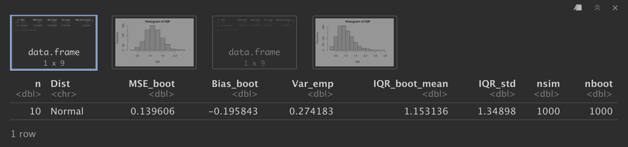

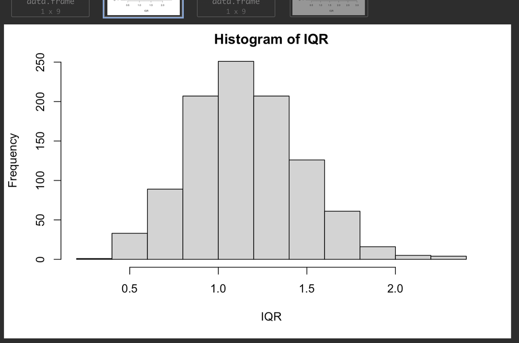

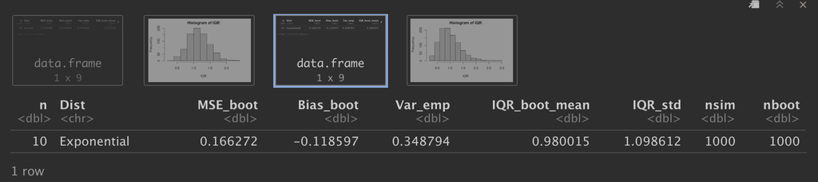

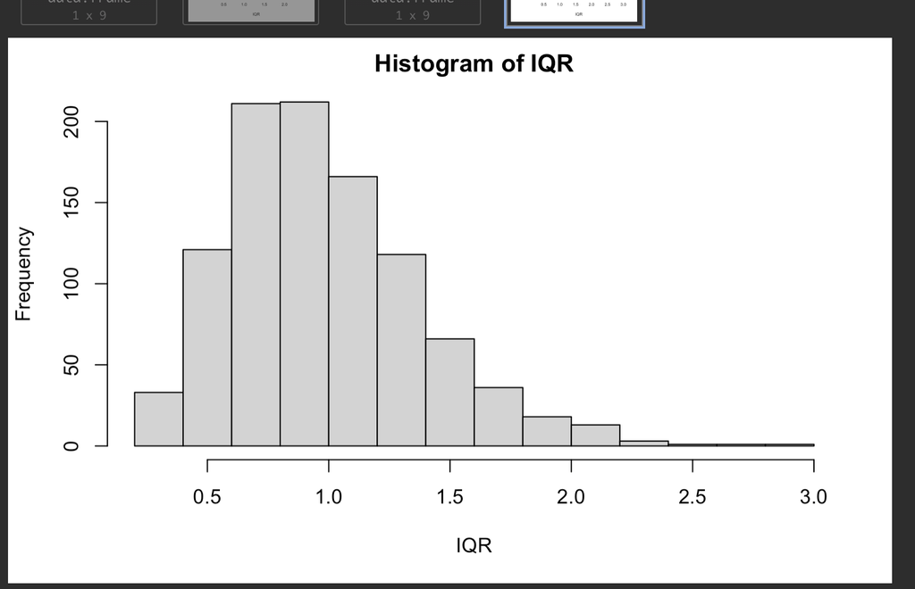

```r
# Clear the environment
rm(list = ls())

# Build the function simu_IQR
simu_IQR <- function(Dist,n,nsim,nboot){

  # Create some containers
  IQR <- c()
  IQR_var <- c()

  # Generate data from different distributions
  if(Dist == "Normal") {
    x <- matrix(rnorm(n*nsim, mean = 0, sd = 1),ncol = nsim)
    IQR_std <- diff(qnorm(c(0.25, 0.75), mean = 0, sd = 1))
  }
  if(Dist == "Exponential") {
    x <- matrix((rexp(n = n*nsim, rate = 1) - 1) / sqrt(1), ncol = nsim)
    IQR_std <- diff(qexp(c(0.25, 0.75),rate = 1))
  }

  # Helping Matrix for Non-parametric Bootstrap
  B <- apply(matrix(1:n, ncol = nboot, nrow = n), 2, sample, replace = TRUE)

  # Bootstrap
  for(i in 1:nsim){
    xi <- x[,i]
    xstar <- matrix(xi[B], ncol = nboot, nrow = n)
    IQR_star <- apply(xstar,2,IQR)
    IQR[i] <- mean(IQR_star)
    IQR_var[i] <- var(IQR_star)
  }

  #Plot a histogram of the distribution of the point estimate
  hist(IQR)

  # MSE and Bias as a measure to compare my results
  # with the functions qnorm and qexp
  MSEstar <- mean((IQR - IQR_std)^2)
  Biasstar <- mean(IQR - IQR_std)


  result <- data.frame(n = n, Dist = Dist, MSE_boot = round(MSEstar,6), Bias_boot = round(Biasstar,6), Var_emp = round(mean(IQR_var),6) ,IQR_boot_mean = round(mean(IQR),6), IQR_std = round(IQR_std,6), nsim = nsim, nboot = nboot)
  result
}

set.seed(1)
simu_IQR("Normal", 10,1000,1000)
simu_IQR("Exponential", 10,1000,1000)
```

Result: Comparing to the IQR with the inbuilt functions, the mean square error of IQR via resampling method of N(0,1) are lower than that of Exp(1). Also, the variability of their empirical versions of N(0,1) is also lower than that of exp(1). But generally, the biases are small.

## 2.2 Second

Q: Find a 95% confidence interval for the IQR and investigate its coverage probability using nsim = 10000 and nboot = 1000 simulation and bootstrap runs for both distributions with sample sizes n $\in$ {10, 20, 30, 40}

A:

```r
simu_IQR_CI <- function(Dist,n,nsim,nboot){

  # Create some containers
  erg <- c()
  IQR_var <- c()
  IQR <- c()
  lower <- c()
  upper <- c()

  # Generate data from different distributions
  if(Dist == "Normal") {
    x <- matrix(rnorm(n*nsim, mean = 0, sd = 1),ncol = nsim)
    IQR_std <- diff(qnorm(c(0.25, 0.75), mean = 0, sd = 1))
  }
  if(Dist == "Exponential") {
    x <- matrix((rexp(n = n*nsim, rate = 1) - 1) / sqrt(1), ncol = nsim)
    IQR_std <- diff(qexp(c(0.25, 0.75),rate = 1))
  }

  # Helping Matrix for Non-parametric Bootstrap
  B <- apply(matrix(1:n, ncol = nboot, nrow = n), 2, sample, replace = TRUE)

  # Bootstrap
  for(i in 1:nsim){
    xi <- x[,i]
    xstar <- matrix(xi[B], ncol = nboot, nrow = n)
    IQR_star <- apply(xstar,2,IQR)
    IQR[i] <- mean(IQR_star)

    # Compute 95% CI
    lower[i] <- quantile(IQR_star,0.025)
    upper[i] <- quantile(IQR_star,0.975)
    erg[i] <- ((lower[i] < IQR_std) && (upper[i] > IQR_std))
  }

  # Display the results
  result <- data.frame(Dist = Dist, n = n, IQR_boot_mean = round(mean(IQR),6), lowerCI = round(mean(lower),6), upperCI = round(mean(upper),6), coverage_p = mean(erg))
  write.table(result, row.names = FALSE, col.names = FALSE, quote = FALSE, append = TRUE)
  return(result)
}

nsim <- 1000
nboot <- 1000
n <- c(10,20,30,40)
Dist <- c("Normal","Exponential")
set.seed(1)
for(h in 1:length(n)){
  for(i in 1:length(Dist)){
      simu_IQR_CI(Dist[i],n[h],nsim,nboot)
  }
}
```

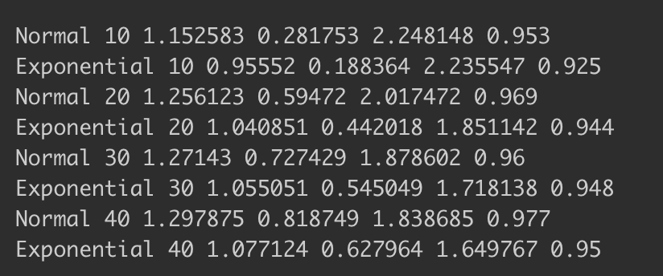

Result: Generally, the larger the data set, the higher the coverage probability. According to the coverage probability, the test of N(0,1) is more conservative than that of Exp(1).

## 2.3 Third

Compute the 95%-precision interval for the empirical coverage probability and state your conclusion in 1- 2 sentences.

```r
(PI_l <- 0.95-1.96/1000 * sqrt(0.95*(1-0.95)))
```

```
## [1] 0.9495728
```

```r
(PI_u <- 0.95+1.96/1000 * sqrt(0.95*(1-0.95)))
```

```
## [1] 0.9504272
```

Conclusion: When n is small, the procedure of calculating IQR under N(0,1) is more accurate. As the n increases, this procedure under Exp(1) is more accurate.

# 3 Question 3

In a toxicity study using N = 29 female Wistar rats, undesired effects of a drug on the rat’s fertility were examined by determining the numbers of corpora lutea after dissection. The results of $n_1 = 12$ animals in the placebo group and the $n_2 = 17$ animals who received the drug are given in the table below.

```r
# Clear the environment
rm(list = ls())

# Input the data
Placebo <- c(3, 3, 4, 10, 10, 10, 11, 12, 12, 13, 17, 19)
Drug <- c(4, 9, 11, 12, 12, 13, 13, 13, 13, 13, 13, 13, 13, 14, 14, 18, 23)
```

## 3.1 First

Q: Analyze the data descriptively and state your own interpretation of the results.

A:

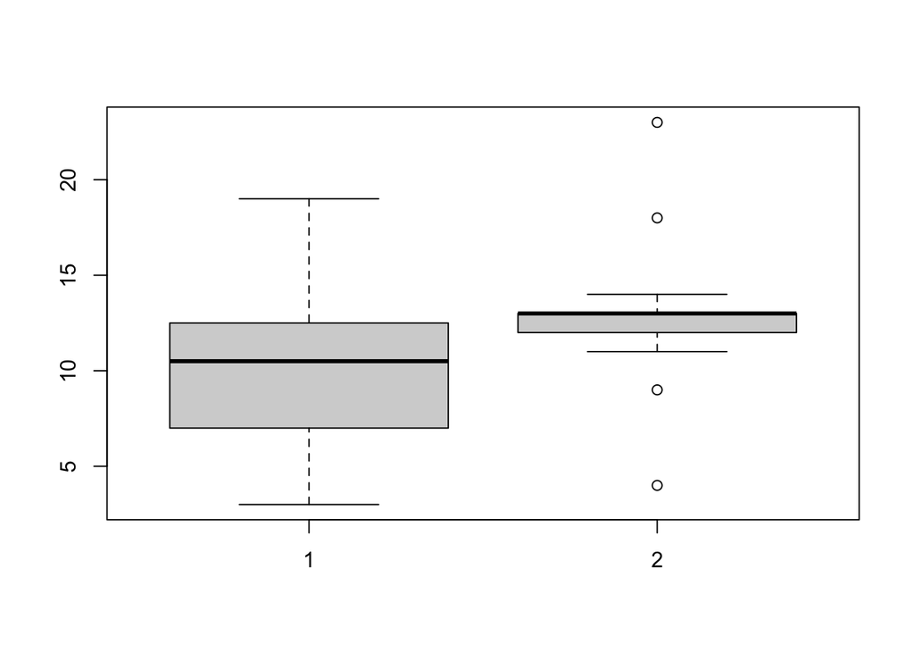

```r
boxplot(Placebo,Drug)
```

Interpretation: The number of corpora lutea in the treatment group (drug) is generally larger than that in the placebo group, and the variance is also generally smaller than that in the placebo group. But there exists several outliers in the treatment group, while the placebo group does not have such extreme values.

## 3.2 Second

Q: Can the data be modeled by a Poisson distribution or a negative binomial distribution? Explain your answer.

A:

```r
# Store the length of data
np = length(Placebo)
nd = length(Drug)

# Reformulate the data
les = data.frame(res = c(Placebo,Drug),
                 grp = factor(c(rep(1,np),rep(2,nd))))
les
```

```
##    res grp
## 1    3   1
## 2    3   1
## 3    4   1
## 4   10   1
## 5   10   1
## 6   10   1
## 7   11   1
## 8   12   1
## 9   12   1
## 10  13   1
## 11  17   1
## 12  19   1
## 13   4   2
## 14   9   2
## 15  11   2
## 16  12   2
## 17  12   2
## 18  13   2
## 19  13   2
## 20  13   2
## 21  13   2
## 22  13   2
## 23  13   2
## 24  13   2
## 25  13   2
## 26  14   2
## 27  14   2
## 28  18   2
## 29  23   2
```

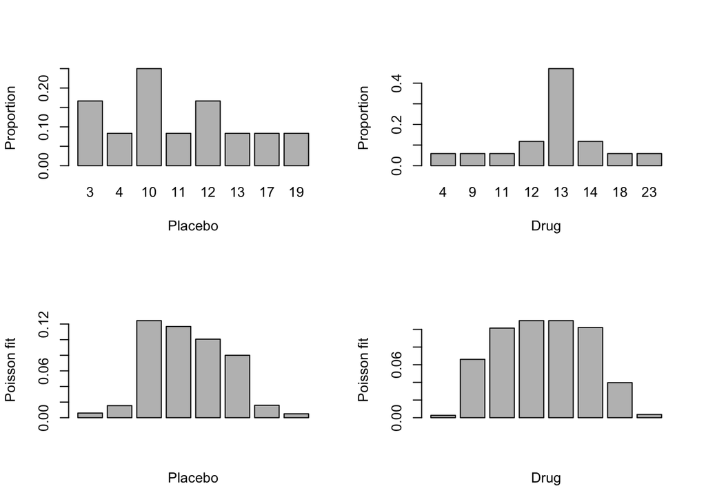

```r
# Calculate the empirical mean
mp <- mean(Placebo)
md <- mean(Drug)

# Calculate the empirical variance
vp <- var(Placebo)
vd <- var(Drug)

# Whether poisson distribution
# Perform a model fit with a poisson distribution, i.e., compute the
# probabilities P(Xik = xik) assuming data is coming from poisson
# distributions with rates λi,i = 1,2, and compare the results with the relative frequencies.

pp <- exp(-mp)*mp^Placebo/factorial(Placebo)
pd <- exp(-md)*md^Drug/factorial(Drug)

# relative frequencies
data_p <- cbind(Placebo,pp)
data_p <- unique(data_p[order(Placebo),])

data_d <- cbind(Drug,pd)
data_d <- unique(data_d[order(Drug),])

p <- as.numeric(names(table(Placebo)))
d <- as.numeric(names(table(Drug)))

# Frequencies if we use Poisson to fit the data
p_fitted <- exp(-mp) * mp^p / factorial(p)
d_fitted <- exp(-md) * md^d / factorial(d)

# Plot
par(mfrow=c(2,2))
barplot(table(Placebo)/length(Placebo),xlab = "Placebo",ylab = "Proportion")
barplot(table(Drug)/length(Drug),xlab = "Drug",ylab = "Proportion")
barplot(p_fitted,xlab = "Placebo",ylab = "Poisson fit")
barplot(d_fitted,xlab = "Drug",ylab = "Poisson fit")
```

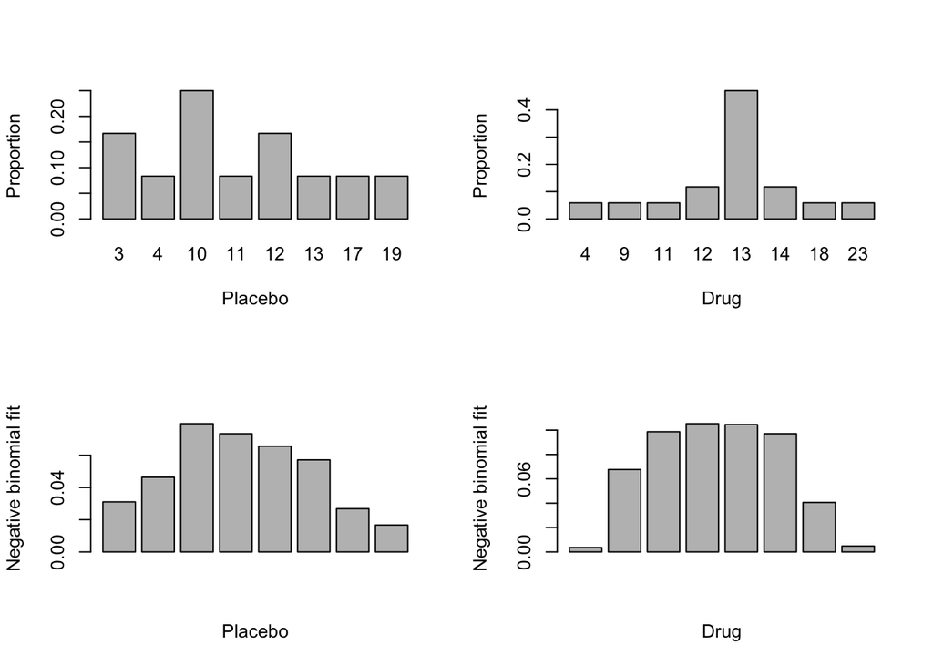

```r
# Whether negative binomial distribution
# Perform a model fit with a negative binomial distribution, i.e., compute
# the probabilities P(Xik = xik) assuming data is coming from poisson
# distributions with rates λi,i = 1,2, and compare the results with the
# relative frequencies.
rp <- mp^2/(vp-mp)
rd <- md^2/(vd-md)
p1 <- mp/vp
p2 <- md/vd

nbp <- (gamma(rp+Placebo)/(factorial(Placebo)*gamma(rp)))*(p1^rp)*((1-p1)^Placebo)
nbd <- (gamma(rd+Drug)/(factorial(Drug)*gamma(rd)))*(p2^rd)*((1-p2)^Drug)

# Relative frequencies
data_p <- cbind(Placebo,nbp)
data_p <- unique(data_p[order(Placebo),])

data_d <- cbind(Drug,nbd)
data_d <- unique(data_d[order(Drug),])

p <- as.numeric(names(table(Placebo)))
d <- as.numeric(names(table(Drug)))
p_fitted <- (gamma(rp+p)/(factorial(p)*gamma(rp)))*(p1^rp)*((1-p1)^p)
d_fitted <- (gamma(rd+d)/(factorial(d)*gamma(rd)))*(p2^rd)*((1-p2)^d)


par(mfrow=c(2,2))
barplot(table(Placebo)/length(Placebo),xlab = "Placebo",ylab = "Proportion")
barplot(table(Drug)/length(Drug),xlab = "Drug",ylab = "Proportion")
barplot(p_fitted,xlab = "Placebo",ylab = "Negative binomial fit")
barplot(d_fitted,xlab = "Drug",ylab = "Negative binomial fit")
```

## 3.3 Third

Use an appropriate inference method to investigate whether the drug has an impact on the fertility at 5% level of significance. Calculate the estimated treatment effect also “by hand” using R (do not simply report the output of the R function).

```r
# Testing null hypotheses of no treatment effect using poisson and negative binomial regression

data <- data.frame(typo = c(Placebo,Drug), grp = c(rep("p",np), rep("d",nd)))

# Poisson regression

fitPois <- glm(typo ~ grp, data = data, family = "poisson")
summary(fitPois)
```

```
##
## Call:
## glm(formula = typo ~ grp, family = "poisson", data = data)
##
## Deviance Residuals:
##     Min       1Q   Median       3Q      Max
## -2.9276  -0.2810   0.0000   0.2739   2.4990
##
## Coefficients:
##             Estimate Std. Error z value Pr(>|z|)
## (Intercept)  2.56495    0.06727  38.131   <2e-16 ***
## grpp        -0.22957    0.11220  -2.046   0.0407 *
## ---
## Signif. codes:  0 '***' 0.001 '**' 0.01 '*' 0.05 '.' 0.1 ' ' 1
##
## (Dispersion parameter for poisson family taken to be 1)
##
##     Null deviance: 53.006  on 28  degrees of freedom
## Residual deviance: 48.736  on 27  degrees of freedom
## AIC: 175.53
##
## Number of Fisher Scoring iterations: 4
```

```r
# There seems to be a treatment effect, estimate is -0.22957, Std. Error = 0.11220, pvalue = 0.0407
# Therefore, we can reject the null hypothesis of no effect

# Negative Binomial
library(MASS)
fitNB <- glm.nb(typo ~ grp, data = data)
summary(fitNB)
```

```
##
## Call:
## glm.nb(formula = typo ~ grp, data = data, init.theta = 20.0801168,
##     link = log)
##
## Deviance Residuals:
##     Min       1Q   Median       3Q      Max
## -2.4215  -0.2201   0.0000   0.2124   1.8835
##
## Coefficients:
##             Estimate Std. Error z value Pr(>|z|)
## (Intercept)  2.56495    0.08634  29.708   <2e-16 ***
## grpp        -0.22957    0.14025  -1.637    0.102
## ---
## Signif. codes:  0 '***' 0.001 '**' 0.01 '*' 0.05 '.' 0.1 ' ' 1
##
## (Dispersion parameter for Negative Binomial(20.0801) family taken to be 1)
##
##     Null deviance: 35.157  on 28  degrees of freedom
## Residual deviance: 32.460  on 27  degrees of freedom
## AIC: 174.55
##
## Number of Fisher Scoring iterations: 1
##
##
##               Theta:  20.1
##           Std. Err.:  15.6
##
##  2 x log-likelihood:  -168.549
```

```r
# There seems to be no treatment effect, estimate is -0.22957, Std. Error = 0.14025, pvalue = 0.102
# Therefore, we cannot reject the null hypothesis of no effect

# In this data example, there is some overdispersion, which means that the Negative Binomial Regression gives different results as the Poisson regression

# 4. Calculating treatment effect using means for Poisson and Negative Binomial Regression
log(mp/md)
```

```
## [1] -0.2295744
```

```r
# Calculation of standard error for Poisson Regression
sqrt(mp/np/mp^2 + md/nd/md^2)
```

```
## [1] 0.1122025
```

```r
# Calculation of standard error for Negative Binomial Regression using Theta, here yields a different result as the Poisson Regression. Thus, we get different p-values

theta <- 20.1
sqrt(((mp+(mp^2/theta))/np)/mp^2 + ((md+(md^2/theta ))/nd)/md^2)
```

```
## [1] 0.1402208
```

## 3.4 Fourth

Q: Make a summary of your results and state your conclusions.

A: Because there is a over-dispersion parameter, negative binomial distribution fits our data better. From the result of negative binomial regression, there seems to be no treatment effect, estimate is -0.22957, Std. Error = 0.14025, pvalue = 0.102. Therefore, we cannot reject the null hypothesis of no effect.

# 4 Question 4

Consider paired data $X_k = (X_{1k};X_{2k}), k = 1,...,n$ and $X_{ik} \sim F_i, i = 1, 2$ with $F_i$ being any distribution function. Furthermore, we define the relative (marginal) treatment effect as

$p = P(X_{11} < X_{22}) + \frac{1}{2}P(X_{11} = X_{22}).$

## 4.1 First

Q: Explain the model in detail and state the underlying assumptions.

A: If we consider i=1 as group1, i=2 as group2, group1 and group2 are normally based on the same observations but in different conditions or time points. Thus, they might come from different distributions. In this model, we aim to implement a comparison between such paired-groups.

Underlying assumptions:

- data is ordinal, and in this case, comparison of means is inappropriate
- data is paired; Hence, they are not independent

## 4.2 Second

Q: Explain in your own words how the relative effect p can be interpreted.

A: The relative effect p could be interpreted as %(group1 < group2) +(1/2)%(group1 = group2), which measures whether values are different between the groups.

- if p<0.5: Group1 tends to be larger than Group2
- if p>0.5: Group1 tends to be smaller than Group2
- if p=0.5: No tendency to smaller or larger values

## 4.3 Third

Q: Give three examples of research questions that could be answered with the relative effect p.

A:

- What is the probability that men are taller than women?
- What is the probability, blood pressure under treatment is higher than under control?
- What is the impact of a treatment program? e.g. the difference of mental well being of participants between their first meeting and after 3 months on an ordinal scale with 1 = very happy and 10 = very unhappy

## 4.4 Fourth

Q: We are interested in estimating p and in particular finding a 95% confidence interval thereof. Propose three different ways and compare the methods in a simulation study in the following setups:

A:

```r
# Clear the environment
rm(list = ls())

library(mvtnorm, quietly = TRUE)

# Inside the function, nperm and nboot are both set to 10000
testdifference <- function(n, Dist, sigma, nsim){
  mu = c(0,0)
  n1 <- n+1
  n2 <- 2*n
  x <- matrix(0,ncol = nsim,nrow = n2)
  for(i in 1:nsim){
    # Generate paired data
    if (Dist == "Normal") {
      xd <- rmvnorm(n = n, mean = mu, sigma = sigma)
    }
    if (Dist == "LogNor") {
      xd <- exp(rmvnorm(n = n, mean = mu, sigma = sigma))
    }

    xstar <- matrix(xd[, 1], nrow = n)
    ystar <- matrix(xd[, 2], nrow = n)

    x[,i] = rbind(xstar,ystar)
  }


  # Munzel test
  tcrit <- qt(0.975,n-1)
  x1 <- x[1:n,]
  x2 <- x[n1:n2,]

  # Overall ranks
  rx <- apply(x, 2, rank)

  rx1 <- colMeans(rx[1:n,])
  rx2 <- colMeans(rx[n1:n2,])

  phat <- 1/(2*n)*(rx1-rx2)+1/2

  # Calculate internal ranks
  rix1 <- apply(x1,2,rank)
  rix2 <- apply(x2,2,rank)

  BM1 <- 1/n*(rx1-rix1)
  BM2 <- 1/n*(rx2-rix2)

  BM3 <- BM1-BM2
  BM4 <- 1/(2*n)*(rx1-rx2)
  pd <- colMeans(BM2)
  m <- colMeans(BM3)

  # Variance estimator
  v <- (colSums(BM3^2)-n*m^2)/(n-1)

  # Confidence interval
  SE <- sqrt(v)/sqrt(n)
  Lower_Munzel <- phat - tcrit*SE
  Upper_Munzel <- phat + tcrit*SE

  # Permutation

  # Number of permutations
  nperm <- 100

  # Permutation matrix
  P <- matrix(0, nrow = (2*n), ncol = nperm)
  for(h in 1:nperm){
    P[,h] <- c(t(apply(cbind(1:n,(n+1):(2*n)),1,sample)))
  }

  Lower_p <- c()
  Upper_p <- c()

  for(s in 1:nsim){
    xs <- x[,s] #the sth column of x
    rs <- rx[,s] #the sth colum of the rank of x

    # Permute raw data
    xperm <- matrix(xs[P],nrow = n2,ncol = nperm)

    # Permute ranks
    rxperm <- matrix(rs[P],nrow = n2,ncol = nperm)

    # Permuted data in both "groups"
    xperm1 <- xperm[1:n,]
    xperm2 <- xperm[n1:n2,]

    # Permuted ranks in both "groups"
    rperm1 <- rxperm[1:n,]
    rperm2 <- rxperm[n1:n2,]

    # Internal ranks within the "groups"
    riperm1 <- apply(xperm1,2,rank)
    riperm2 <- apply(xperm2,2,rank)

    BMperm2 <- 1/n*(rperm2-riperm2)
    BMperm3 <- 1/n*(rperm1-riperm1)-BMperm2

    # Relative effect (Permutation version)
    pdperm <- colMeans(BMperm2)
    mperm3 <- colMeans(BMperm3)
    vperm3 <- (colSums(BMperm3^2)-n*mperm3^2)/(n-1)
    vperm30 <- (vperm3==0)
    vperm3[vperm30] <- 1/n

    # Permutation Test Statistic
    Tperm <- sqrt(n)*(pdperm-1/2)/sqrt(vperm3)

    # Confidence interval
    Lower_p[s] <- mean(mean(pdperm) + quantile(Tperm, 0.025)[[1]]*SE)
    Upper_p[s] <- mean(mean(pdperm) + quantile(Tperm, 0.975)[[1]]*SE)
  }

  #Wild bootstrap

  nboot <- 100

  # Generate random weights
  WN <- matrix(rnorm(nboot*2*n), nrow = 2*n, ncol = nboot)

  mx <- colMeans(x)

  # Center data
  mxmat <- matrix(mx, nrow = 2*n, ncol = nsim, byrow = TRUE)
  zmat <- x - mxmat

  zrmat <- rx

  Lower_w <- c()
  Upper_w <- c()

  for (i in 1:nsim) {
    ztemp <- matrix(zmat[, i], nrow = 2*n, ncol = nboot)
    zrtemp <- matrix(zrmat[, i], nrow = 2*n, ncol = nboot)

    # Generate WB resampling data
    xwild <- matrix(WN * ztemp,nrow = n2,ncol = nboot)

    # Generate WB resampling ranks
    rxwild <- matrix(zrtemp ,nrow = n2,ncol = nboot)

    # Permuted data in both "groups"
    xwild1 <- xwild[1:n,]
    xwild2 <- xwild[n1:n2,]

    # Permuted ranks in both "groups"
    rwild1 <- rxwild[1:n,]
    rwild2 <- rxwild[n1:n2,]

    # Internal ranks within the "groups"
    riwild1 <- apply(xwild1,2,rank)
    riwild2 <- apply(xwild2,2,rank)

    BMwild2 <- 1/n*(rwild2-riwild2)
    BMwild3 <- 1/n*(rwild1-riwild1)-BMwild2

    # Relative effect (Permutation version)
    pdwild <- colMeans(BMwild2)
    mwild3 <- colMeans(BMwild3)
    vwild3 <- (colSums(BMwild3^2)-n*mwild3^2)/(n-1)
    vwild30 <- (vwild3==0)
    vwild3[vwild30] <- 1/n

    # Permutation Test Statistic
    Twild <- sqrt(n)*(pdwild-1/2)/sqrt(vwild3)

    # Confidence interval
    Lower_w[i] <- mean(mean(pdwild) + quantile(Twild, 0.025)[[1]]*SE)
    Upper_w[i] <- mean(mean(pdwild) + quantile(Twild, 0.975)[[1]]*SE)
  }

    # Display the results
    result <- data.frame(Dist = Dist, n = n, p_Munzel = round(mean(phat),6), CI_Munzel_L = round(mean(Lower_Munzel),6), CI_Munzel_U=round(mean(Upper_Munzel),6), p_permute = round(mean(pdperm),6), CI_permute_L = round(mean(Lower_p),6), CI_permute_U = round(mean(Upper_p),6), p_wild = round(mean(pdwild),6), CI_wild_L = round(mean(Lower_w),6),CI_wild_U = round(mean(Upper_w),6))
    write.table(result, row.names = FALSE, col.names = FALSE, quote = FALSE, append = TRUE)
    return(result)
}


nsim <- 100
n <- c(10,20,30)
Dist <- c("Normal","LogNor")

set.seed(1)
for(h in 1:length(n)){
  for(hh in 1:length(Dist)){
    testdifference(n[h],Dist[hh],diag(2),nsim)
    testdifference(n[h],Dist[hh],diag(c(1,2)),nsim)
    testdifference(n[h],Dist[hh],diag(c(1,2)) + 0.8 * (1 - diag(2)),nsim)
  }
}
```

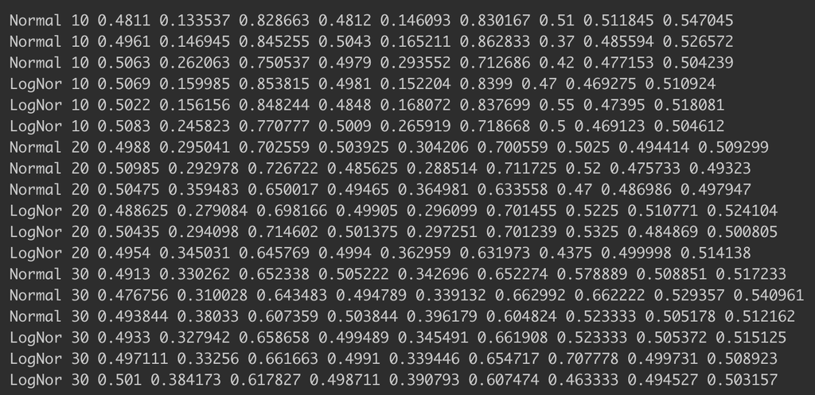

## 4.5 Fifth

Q: Present and interpret your results. Which method would you recommend? State your conclusion in 1-2 sentences.

A: Because we set means are equal, p should be 1/2 no matter how covariance varies. From the result of normal Munzel test ,permutation test and wild bootstrap test, we could see that the permutation one is more stable with $\hat{p}$ being around 1/2 and its confidence interval is narrower than normal Munzel’s. Therefore, I recommend the permutation method.

# 5 Question 5

Consider the alpha dataset available in the R-package coin. Various studies have linked alcohol dependence phenotypes to chromosome 4. One candidate gene is NACP (non-amyloid component of plaques), coding for alpha synuclein. Researchers found longer alleles of NACP-REP1 in alcohol-dependent patients compared with healthy controls and reported that the allele lengths show some association with levels of expressed alpha synuclein mRNA.

Here, we are interested in comparing the mean expression levels of alpha synuclein mRNA in the three groups of subjects defined by allele length.

```r
# Clear the environment
rm(list = ls())

library(coin)
```

```r
library(ggplot2)
data(alpha)
summary(alpha)
```

```
##          alength       elevel
##  short       :24   Min.   :-2.830
##  intermediate:58   1st Qu.: 1.470
##  long        :15   Median : 2.770
##                    Mean   : 2.341
##                    3rd Qu.: 3.370
##                    Max.   : 5.800
```

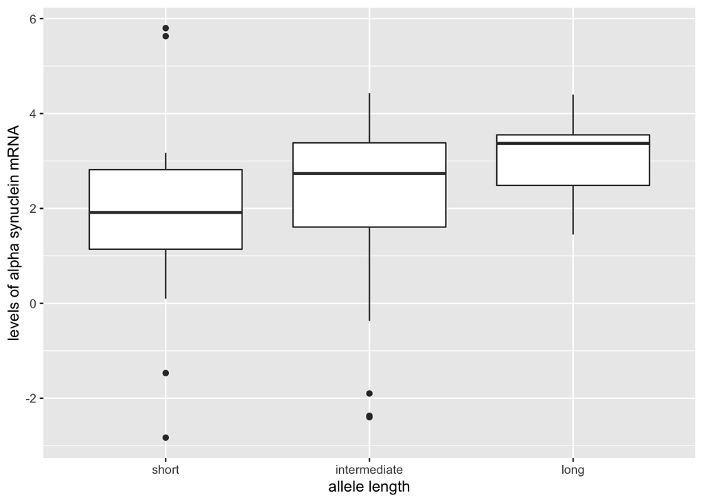

```r
ggplot(data = alpha, aes(x = alength, y = elevel ))+
  geom_boxplot()+
  labs(y = "levels of alpha synuclein mRNA", x = "allele length")
```

## 5.1 First

Q: Find a statistical model to describe the data and interpret its parameters and components.

A: $X_{ik} \sim N(\mu_i,\sigma^2), i=1,2,3;k=1,...,n_i;n_1=24,n_2=58,n_3=15; \pmb{\mu}=(\mu_1,\mu_2,\mu_3)'$

Here, $X_{ik}$ is the levels of alpha synclein in different allele lengths, $\mu$ denotes the mean.

Hypothesis $H_0: C\mu=0 \quad vs. \quad H_1: C\mu≠0$; contrast matrix C is nothing but the pattern of the alternative $H_1$

In this case, we are interested in comparing the mean expression levels of alpha synuclein mRNA in the three groups of subjects defined by allele length:

```r
library(multcomp,quietly = TRUE)
C <- contrMat(rep(1,3),"Tukey")
C
```

```
##
##   Multiple Comparisons of Means: Tukey Contrasts
##
##        1  2 3
## 2 - 1 -1  1 0
## 3 - 1 -1  0 1
## 3 - 2  0 -1 1
```

## 5.2 Second

Q: Can we conclude that any of the three allele mean lengths is significantly different from the other two allele mean lengths at 5% significance level? Choose an appropriate method and explain your choice including all parameters.

A:

Here I use ANOVA to compute a multiple contrast test, because each group has different number of observations, and their variances differ. Also, I could use this method to do the multiple comparisons test. I would show how to implement the multivariate T-approach in exercise 6 along with the resampling methods.

```r
amod <- aov(elevel~alength, data = alpha)
erg <- glht(amod,linfct = mcp(alength = "Tukey"))
summary(erg)
```

```
##
##   Simultaneous Tests for General Linear Hypotheses
##
## Multiple Comparisons of Means: Tukey Contrasts
##
##
## Fit: aov(formula = elevel ~ alength, data = alpha)
##
## Linear Hypotheses:
##                           Estimate Std. Error t value Pr(>|t|)
## intermediate - short == 0   0.4342     0.3836   1.132   0.4924
## long - short == 0           1.1888     0.5203   2.285   0.0615 .
## long - intermediate == 0    0.7546     0.4579   1.648   0.2271
## ---
## Signif. codes:  0 '***' 0.001 '**' 0.01 '*' 0.05 '.' 0.1 ' ' 1
## (Adjusted p values reported -- single-step method)
```

From the result we can see that each pair of comparison is not significant at 5% significance level, which means that we cannot conclude that any of the three allele mean lengths is significantly different from the other two allele mean lengths at 5% significance level. In this test, I use “Tukey”-type Contrast matrix like I explained before, elevel as target variable and alength as group that need to be compared. The result should be very similar to the one that we conduct multiple contrast test procedures from scratch.

## 5.3 Third

Q: Compute 95% two-sided simultaneous confidence intervals and interpret the results in 1-2 sentences.

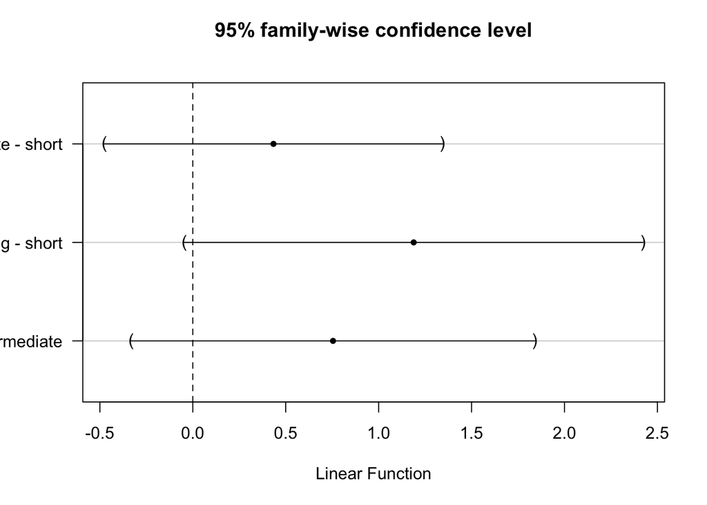

```r
plot(erg)
```

Interpretation: The confidence intervals of all pairs cover 0 simultaneously, which means that they do not have enough evidence to reject the $H_0$: there is no difference in all pairs of comparison.

# 6 Question 6

Consider independent samples $X_{ik} = F_i, i = 1,...,a, k = 1,...,n_i$ with $E(X_{ik}) = \mu_i$ and $Var(X_{ik}) = {\sigma_i}^2$.

We are interested in testing the null hypothesis

$H_0: C\pmb{\mu} = 0$

with an arbitrary contrast matrix $C$. Here $\pmb{\mu} = (\mu_1,...,\mu_a)'$ denotes the vector of expectations.

## 6.1 First

Q: Explain the model in detail and state the underlying assumptions as well how the parameters are estimated.

A: In this statistical model, samples are independent in each class ($a$ classes in total). Each class has its sample size $n_i, i =1,...,a$, mean $\mu_i, i =1,...,a$ and variance $\sigma_i^2, i =1,...,a$. We are interested in multiple comparisons, so we assign the contrast matrix $C$ to describe the pattern of the alternative $H_1$. If $H_0$ cannot be rejected, then there is no difference in all kinds of comparisons described in $C$. In other words, we have many comparison tasks and they could be represented in a contrast matrix $C$. The means and variances of all classes could be estimated by their empirical means and variances respectively.

- Mean: $\bar{\pmb{X}.} = (\bar{X_{1.}},...,\bar{X_{a.}})'$
- Variance: $s^2_i = \frac{1}{n_i-1}\sum_{k=1}^{n_i}(X_{ik}-\bar{X_{i.}})^2$

## 6.2 Second

Q: Propose a multiple contrast test procedure to test the null hypothesis.

A: First, we define our model and hypothesis, and set a suitable contrast matrix X. Second, we estimate the means, variances, variance of a contrast, and use these estimators to build our statistics in all comparisons. If any of the statistics are enough to reject $H_0$, then we could spot it and distinguish which null hypothesis could be rejected according to our result. Also, we would use the distribution of the maximum value $T_0$ to compute the critical value for the maximum of absolute value of statistics. Finally, we draw a conclusion based on our result.

## 6.3 Third

Q: Propose and explain the nonparametric and parametric bootstrap strategies for testing the null hypothesis.

A: Our goal of using resampling methods is to improve the approximation/method, i.e. to approximate the distribution of the maximum, since the original method is a multiple t-test and it might be liberal or conservative in case of small samples.

Both nonparametric and parametric bootstrap will generate resampling variables from our original data, and reassign the new data to different classes respectively. Then we compute empirical means and empirical variances with the resampling variables. Based on these, we could compute the vector of test statistics and get the maximum from them. Repeat the above nboot times and estimate the $(1-\alpha)$ quantile from all the maximums. At the end we will use it to test our null hypothesis.

The only difference between nonparametric and parametric bootstrap is how we generate the resampling variables. The former one draws with replacement from original fixed values; the latter randomly draw observations from $N(0,\hat{s_i}^2)$

## 6.4 Fourth

Q: Conduct a simulation study to assess the type-I error rates of the procedures at 5% level of significance.

- Simulate normal, log-normal and exponentially distributed data.
- Set the number of groups to a = 3.
- Investigate balanced $n_i \equiv n = 30$ as well as unbalanced designs with n1 = 20, n2 = 25, n3 = 30.
- Set the variance to $\sigma_i^2 = 1 \forall i \in{1,...,a)}$ and to$\sigma_1^2 = 1, \sigma_2^2 = 1.5,\sigma_3^2 = 2$.
- Use the Tukey-type contrast matrix $C$.

A:

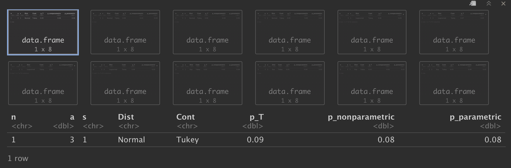

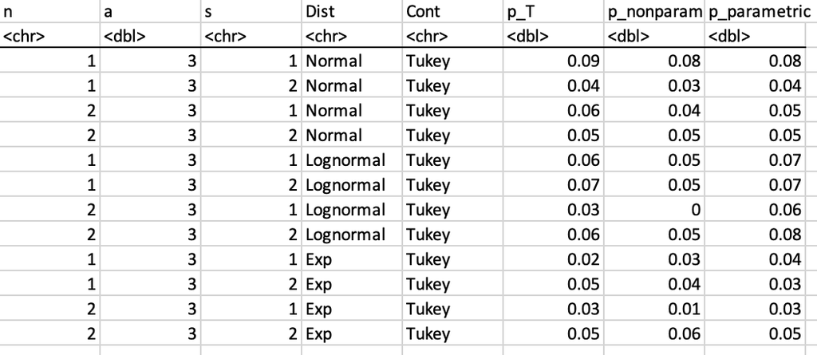

```r
# Clear the environment
rm(list = ls())

library(multcomp,quietly = TRUE)

mySimulation <- function(a, n, s, cont, dist, nsim, nboot){

  # Result vector
  p0 <- c()
  p1 <- c()
  p2 <- c()

  # Number of observations per group
  if(n == "1") nii <- rep(30,a)
  if(n == "2") nii <- c(20,25,30)

  # Identical variances or estimated variances from previous exercise
  if(s == "1") sigma2 <- rep(1,a)
  if(s == "2") sigma2 <- c(1,1.5,2)

  # Contrast Matrix
  C <- matrix(contrMat(nii, type = cont), ncol = a)
  nc <- nrow(C)

  # Number of all observations
  N <- sum(nii)

  # Data generation
  vvec <- c()
  gp <- c()
  i <- 1
  while (i <= a) {
    vvec <- c(vvec, rep(sigma2[i], nii[i]))
    gp <- c(gp, rep(i, nii[i]))
    i <- i + 1
  }

  # Simulate the standardized data
  if (dist == "Normal") {
    x0 <- matrix(rnorm(N*nsim), ncol = nsim)
  }

  if(dist == "Lognormal"){
    x0 <- matrix(((exp(rnorm(n = N*nsim, mean = 0, sd = 1)) - exp(1/2)) / sqrt(exp(1)*(exp(1)-1))), ncol = nsim)
  }

  if(dist == "Exp"){
    x0 <- matrix(rexp(N*nsim)-1, ncol = nsim)
  }

  # Assigning variances
  x <- vvec*x0

  gp <- as.factor(gp)

  # Start of Simulation
  for (j in 1:nsim) {
    # Subsetting
    Data_v <- data.frame(XV=x[, j], grp=gp)

    # Calculating means and variances of contrasts
    vmean <- aggregate(XV~grp,data = Data_v, mean)[,2]
    vvar <- aggregate(XV~grp,data = Data_v, var)[,2]
    vmat <- diag(vvar/nii)
    Cmu <- C%*%vmean
    CV <- C%*%vmat%*%t(C)

    # Correlation Matrix
    R <- cov2cor(CV)

    # Degree of freedom
    nul <- sapply(1:nrow(C),function(arg){c(t(C[arg,])%*%vmat%*%C[arg,])^2/sum(C[arg,]^4*vvar^2/(nii^2*(nii-1)))})
    nu <- round(min(nul))

    # Test statistic
    TT <- Cmu / sqrt(c(diag(CV)))
    T0 <- max(abs(TT))

    pval <- 1 - pmvt(lower = -T0, upper = T0, delta = rep(0, nc), df = nu, corr = R)[1]
    p0[j] <- (pval < 0.05)

    # First nonparametric
    NP <- c()
    TlNP <- matrix(rep(0,a*nboot), ncol = nboot)

    for(h in 1:nboot){
      if(length(unique(nii))==1){
        n0 <- unique(nii)
    # Draw with replacement from data, observation-wise
        ind <- sample(c(1:n0),n0,replace = TRUE)

        XNP1 <- Data_v[1:n0,1][ind]
        XNP2 <- Data_v[(n0+1):(2*n0),1][ind]
        XNP3 <- Data_v[(2*n0+1):(3*n0),1][ind]
        XNP <- data.frame(XN=c(XNP1,XNP2,XNP3), grp=gp)
      }else{
      # Draw with replacement from data, non-observation-wise
        ind1 <- sample(c(1:nii[1]),nii[1],replace = TRUE)
        ind2 <- sample(c(1:nii[2]),nii[2],replace = TRUE)
        ind3 <- sample(c(1:nii[3]),nii[3],replace = TRUE)

        XNP1 <- Data_v[1:nii[1],1][ind1]
        XNP2 <- Data_v[(nii[1]+1):(nii[1]+nii[2]),1][ind2]
        XNP3 <- Data_v[(nii[1]+nii[2]+1):(nii[1]+nii[2]+nii[3]),1][ind3]
        XNP <- data.frame(XN=c(XNP1,XNP2,XNP3), grp=gp)
      }

      XbarNP <- aggregate(XN~grp,data = XNP, mean)[,2]
      VhatNP <- aggregate(XN~grp,data = XNP, var)[,2]

      VmatNP <- diag(VhatNP/nii)

      CXNP <- C%*%(XbarNP-vmean)
      CVNPC <- C%*%VmatNP%*%t(C)

      TlNP[,h] <- CXNP / sqrt(c(diag(CVNPC)))
      NP[h] <- max(abs(TlNP[,h]))
    }
    # pvalue
    p1[j] = mean(NP>=T0)

    # parametric
    P <- c()
    TlP <- matrix(rep(0,a*nboot), ncol = nboot)
    s2vec<-rep(vvar,nii)

    for(h in 1:nboot){

      # Draw new samples according to their empirical variances
      XP <- rnorm(N,0,sqrt(s2vec))
      DatP <- data.frame(XP, grp=gp)

      XbarP <- aggregate(XP~grp,data = DatP, mean)[,2]
      si2P <- aggregate(XP~grp,data = DatP, var)[,2]
      ShatP <- diag(si2P/nii)
      CXP <- C%*%XbarP
      CVPC <- C%*%ShatP%*%t(C)

      TlP[,h] <-CXP / sqrt(c(diag(CVPC)))
      P[h] <- max(abs(TlP[,h]))
    }

    # pvalue
    p2[j] <- mean(P >= T0)
   }
  result <- data.frame(n = n, a = a, s = s, Dist = dist, Cont = cont,p_T = mean(p0),  p_nonparametric = mean(p1<0.05), p_parametric = mean(p2<0.05))
  print(result)
}

n <- c("1","2")
s <- c("1","2")
d <- c("Normal", "Lognormal", "Exp")

set.seed(1)
for(h in 1:length(d)){
  for(hh in 1:length(n)){
    for(hhh in 1:length(s)){
      mySimulation(a = 3, n = n[hh], s = s[hhh], cont = "Tukey", dist = d[h], nsim = 100, nboot = 100)
    }
  }
}
```

## 6.5 Fifth

Q: Present and interpret your results. When are the methods applicable? State your conclusion in 1-2 sentences.

A: When the data is unbalanced and variances differ, all the three methods work well; the nonparametric method is generally more stable and conservative, and it works pretty good especially when data are from lognormal distribution; parametric method performs better when the unbalanced data comes from the normal distribution